# BEM Chap. 10 Notes

2026-02-11

# 1 Settings

The chapter contains some chunks that conduct document settings.

- This chunk **removes all the variables** in the environment.

```r
rm(list = ls(all = TRUE))
```

- This chunk **sets** `knitr` **options**.

```r
knitr::opts_chunk$set(
  block.title = TRUE,
  fig.align = "center",
  results = "hold",
  fig.show = "hold",
  message = FALSE,
  warning = FALSE,
  class.source = 'fold-hide'
)
knitr::opts_hooks$set(label = function(options) {
  options$before = paste0('<div>Chunk: ', options$label, '</div>')
  return(options)
})
```

- This chunk **loads the required packages** and **my functions**.

```r
pkgList <- c(
  "tidyverse", #must-have
  "ggplot2",
  "MASS"
)
easypackages::libraries(pkgList)
rm(pkgList)
```

- This chunk sets **the seed**.

```r
set.seed(1111)
```

# 2 セットアップ

下記の3つが揃うことで、**尤度**を計算可能。

- データ：$X$, $y$
- パラメータ：$\beta$, $\sigma^2 (\text{or }h)$
- モデル：データとパラメータの関係

未知のパラメータは、標準的なOLSに対応している。

モデル：

$$\begin{aligned}
y_t &= \beta_0 + \beta_1 x_t + \epsilon_t,\\[1em]
&\quad \text{or}\\[1em]
y &= X \begin{bmatrix}\beta_0 \\ \beta_1 \end{bmatrix} +
\epsilon,\\[1em]
&\epsilon \sim N(0, \sigma^2I_N)
\end{aligned}$$

データ：
$$y, X$$

パラメータ：
$$\beta, \sigma^2$$

# 3 尤度関数

$\epsilon \sim N(0, \sigma^2I_N)$より、データ$\{y,X\}$が与えられれば、パラメータ$\{\beta, \sigma\}$のjoint distribution、または**尤度**が計算可能。すなわち、
$$\begin{aligned}
p(y|\beta, \sigma^2) &= \prod_{n=1}^N \left[ \frac{1}{\sqrt{2\pi
}\sigma} \exp \left( -\frac{1}{2\sigma^2}\epsilon_n^2 \right) \right]\\
&= \prod_{n=1}^N \left[ \frac{1}{\sqrt{2\pi }\sigma} \exp \left(
-\frac{1}{2\sigma^2}(y_n-X_n \beta)^2 \right) \right]\\
&= \left( \frac{1}{\sqrt{2\pi }\sigma} \right)^N \exp
\left[-\frac{1}{2\sigma^2}\sum_{n=1}^{N} (y_n-X_n \beta)^2 \right] \\
&= \left( \frac{1}{2\pi\sigma^2} \right)^{N/2} \exp \left[
-\frac{1}{2\sigma^2}(y-X\beta)'(y-X\beta) \right].
\end{aligned}$$
または、$h$を使って
$$p(y|\beta, h)= \left( \frac{h}{2\pi} \right)^{N/2} \exp \left[
-\frac{h}{2}(y-X\beta)'(y-X\beta) \right] \quad \text{(Koop 3.3)}.$$

ここで、OLS推定量を
$$\begin{alignat}{2}
\hat{\beta}&=(X'X)^{-1}X'y\\
SSE &= (y - X\hat{\beta})'(y - X\hat{\beta})\\
\hat{\nu} &= N-k && \quad \text{(Koop 3.4)}\\
\hat{s}^2 &= \frac{SSE}{\nu}
\end{alignat}$$
とすると、
$$(y-X\beta)'(y-X\beta)=SSE+(\beta-\hat{\beta})'X'X(\beta-\hat{\beta})=\hat{\nu}\hat{s}^2+(\beta-\hat{\beta})'X'X(\beta-\hat{\beta})$$
より、
$$\boxed{\begin{alignedat}{2}
p(y|\beta, h)&= \left( \frac{h}{2\pi} \right)^{N/2} \exp \left[
-\frac{h}{2}\left\{ \underbrace{ \hat{\nu}\hat{s}^2
}_{=SSE}+(\beta-\hat{\beta})'X'X(\beta-\hat{\beta}) \right\}
\right] &&\quad \text{(BEM 10.4)}, \\
\text{or}\\
p(y|\beta, h)&= \left( \frac{1}{2\pi} \right)^{N/2} \underbrace{
\left\{h^\frac{k}{2} \exp \left[
-\frac{h}{2}(\beta-\hat{\beta})'X'X(\beta-\hat{\beta})
\right]\right\} }_{\text{(Normalっぽい)}} \underbrace{
\left\{h^\frac{\nu}{2} \exp \left[ -\frac{h\nu}{2\hat{s}^{-2}}
\right]\right\} }_{\text{(Gammaっぽい)}} &&\quad \text{(Koop
3.7)}
\end{alignedat}}$$

# 4 事前分布

次に、パラメータ$\{\beta, h\}$について**prior**（事前分布）を当てはめる。ここでは、自然共役分布として、Normal-Gamma分布を考える。Normal-Gamma分布とは、…(def)。ここでは、以下の**Hyperparameter**を考える。

## 4.1 Gamma分布

一般に、Gamma分布の密度関数は、パラメータ$\alpha$、$\beta$を用いて
$$\begin{aligned}
& p(h; \alpha, \beta) ={C_G}^{-1} h^{\alpha - 1} \cdot
e^\frac{-h}{\beta},\\
&\, \text{where }{C_G} = \beta^\alpha\Gamma(\alpha)
\end{aligned}$$
と表現される。

以下では、精度$h$が、$\underline{s}$（スケール）と$\underline{\nu}$（自由度）によって規定されるGamma分布に従うと考える。すなわち、通常のGamma分布との対応関係を、
$$\alpha = {\underline{\nu}}/{2}, \, \beta =
{2\underline{s}^{-2}}/{\underline{\nu}}$$
とする。この時、上の対応関係から、
$$p(h; \underline{s}, \underline{\nu}) ={C_\gamma}^{-1}
h^{\underline{\nu}-2/2} \cdot \exp\left[-\frac{1}{2} h
\frac{\underline{\nu}}{\underline{s}^{-2}}\right]$$
$$\begin{aligned}
\mathbb{E}[h] &= \alpha \beta =
\frac{\underline{\nu}}{2}\frac{2\underline{s}^{-2}}{\underline{\nu}} =
\underline{s}^{-2}\\
\text{Var}[h] &= \alpha \beta^2 =
\frac{\underline{\nu}}{2}\left(\frac{2\underline{s}^{-2}}{\nu}\right)^2
= \frac{2\underline{s}^{-4}}{\underline{\nu}}
\end{aligned}$$
つまり、$\underline{s}$は精度$h$の期待値を調整、$\underline{\nu}$は分散を調整するパラメータである。

## 4.2 正規分布

$β$が$N(\overline{\mathbf{\beta}}, h^{-1}\overline{\mathbf{Q}})$に従う
$$\begin{aligned}
p(\beta|h; \underline{\beta}, \underline{Q}) &=
\frac{1}{2\pi^{\frac{1}{2}k}}|h^{-1}\underline{Q}|^{-\frac{1}{2}}\exp\left[
-\frac{1}{2}(\beta-\underline{\beta})'[h^{-1}\underline{Q}]^{-1}(\beta-\underline{\beta})
\right]\\
&= \frac{1}{2\pi^{\frac{1}{2}k}}\underbrace{ (h^{-k}|\underline{Q}|)
}_{\text{行列式の性質}}^{-\frac{1}{2}}\exp\left[
-\frac{h}{2}(\beta-\underline{\beta})'\underline{Q}^{-1}(\beta-\underline{\beta})
\right]\\
&= \left( \frac{h}{2\pi} \right)^{\frac{1}{2}k}
|\underline{Q}|^{-\frac{1}{2}}\exp\left[
-\frac{h}{2}(\beta-\underline{\beta})'\underline{Q}^{-1}(\beta-\underline{\beta})
\right]
\end{aligned}$$

# 5 事後分布

モデルの**尤度**と**事前分布**が与えられることで、ベイズの定理に基づき**事後分布**を計算することができる。

$$\boxed{\begin{alignedat}{3}
p(y|\beta, h)&= \left( \frac{h}{2\pi} \right)^{N/2} \exp \left[
-\frac{h}{2}\left\{ \nu \hat{s}^2
+(\beta-\hat{\beta})'X'X(\beta-\hat{\beta}) \right\} \right]
&& \quad \dots \text{尤度}\\
p(h; \underline{s}, \underline{\nu}) &={C_\gamma}^{-1}
h^{\underline{\nu}-2/2} \cdot \exp\left[-\frac{1}{2} h
\frac{\underline{\nu}}{\underline{s}^{-2}}\right] && \quad
\dots \text{事前分布（Gamma部分）}\\
p(\beta|h,\underline{\beta}, \underline{Q}) &=\left( \frac{h}{2\pi}
\right)^{k/2} |\underline{Q}|^{-\frac{1}{2}}\exp\left[
-\frac{h}{2}(\beta-\underline{\beta})'\underline{Q}^{-1}(\beta-\underline{\beta})
\right] && \quad \dots \text{事前分布（正規分布部分）}
\end{alignedat}}$$

## 5.1 結合分布

ベイズの定理より、
$$\begin{aligned}
p(\beta, h |y) &\propto \underbrace{p(\beta, h;
\underline{\beta},\underline{Q}, \underline{s},
\underline{\nu})}_{\text{ HPで規定されるparameterの事前分布}} \times
\underbrace{ p(y|\beta, h) }_\text{parameterで条件づけられた尤度}\\
&= \quad p(\beta | h; \underline{\beta},\underline{Q})p(h;
\underline{s}, \underline{\nu}) \quad \times \quad p(y|\beta, h)\\[1em]
\Rightarrow \,p(\beta, h |y) &\propto \left( \frac{h}{2\pi}
\right)^{k/2} |\underline{Q}|^{-\frac{1}{2}}\exp\left[
-\frac{h}{2}(\beta-\underline{\beta})'\underline{Q}^{-1}(\beta-\underline{\beta})
\right]\quad\dots\text{事前分布（正規）}\\
&\quad \quad \times {C_\gamma}^{-1} h^{(\underline{\nu}-2)/2} \cdot
\exp\left[-\frac{h}{2} \frac{\underline{\nu}}{\underline{s}^{-2}}\right]
\quad\dots\text{事前分布（Gamma）}\\
&\quad \quad \times \left( \frac{h}{2\pi} \right)^{N/2} \exp \left[
-\frac{h}{2}\left\{ \hat{\nu} \hat{s}^2
+(\beta-\hat{\beta})'X'X(\beta-\hat{\beta}) \right\} \right]
\quad\dots\text{尤度}\\
& \propto h^{\frac{k+\underline{\nu}-2+N}{2}} \exp \left[
-\frac{h}{2} \left\{\underline{\nu}\underline{s}^{2}+\hat{\nu}
\hat{s}^2+(\beta-\underline{\beta})'\underline{Q}^{-1}(\beta-\underline{\beta})+(\beta-\hat{\beta})'X'X(\beta-\hat{\beta})\right\}
\right].
\end{aligned}$$
ここで、$(\beta-\underline{\beta})'\underline{Q}^{-1}(\beta-\underline{\beta})+(\beta-\hat{\beta})'X'X(\beta-\hat{\beta})$の部分は、

- $(\beta-\underline{\beta})'\underline{Q}^{-1}(\beta-\underline{\beta})$: $\beta$のprior$\underline\beta$からの距離
- $(\beta-\hat{\beta})'X'X(\beta-\hat{\beta})$:$\beta$最尤推定値$\hat\beta$からの距離

と解釈できる。また、後述の書き換え
$$\begin{aligned}
&(\beta-\underline{\beta})'\underline{Q}^{-1}(\beta-\underline{\beta})+(\beta-\hat{\beta})'X'X(\beta-\hat{\beta})\\
=& (\beta-\bar{\beta})'\bar{Q}^{-1}(\beta-\bar{\beta})
+\underbrace{
(\underline{\beta}-\bar{\beta})'\underline{Q}^{-1}(\underline{\beta}-\bar{\beta})
+(\hat{\beta}-\bar{\beta})'X'X(\hat{\beta}-\bar{\beta})
}_{\beta\text{に依存しない！（$h$には依存）}}\\
=& (\beta-\bar{\beta})'\bar{Q}^{-1}(\beta-\bar{\beta})
+(\underline{\beta}-\hat{\beta})'[{\underline{Q}+(X'X)^{-1}}]^{-1}(\underline{\beta}-\hat{\beta})
\end{aligned}$$
を用いると、
$$\boxed{\begin{aligned}
p(\beta,h\mid y) \propto h^{\frac{k+\bar{\nu}-2}{2}} \exp\Bigg[
-\frac{h}{2}\Big\{ &\underline{\nu}\underline{s}^{2}+
\hat{\nu}\hat{s}^2
+(\beta-\bar{\beta})'\bar{Q}^{-1}(\beta-\bar{\beta})\\ &
+(\underline{\beta}-\hat{\beta})'[{\underline{Q}+(X'X)^{-1}}]^{-1}(\underline{\beta}-\hat{\beta})
\Big\} \Bigg],\\
\text{or}\\
p(\beta,h\mid y) \propto h^{\frac{k+\bar{\nu}-2}{2}} \exp\Bigg[
-\frac{h}{2}\Big\{
&(\beta-\bar{\beta})'\bar{Q}^{-1}(\beta-\bar{\beta})+\bar{\nu}
\bar{s}^2
\Big\} \Bigg].
\end{aligned}}$$
$$\boxed{\therefore \beta, h | y \sim NG(\bar{\beta}, \bar{Q},
\bar{s}^{-2}, \bar{\nu})}$$
$$\begin{alignedat}{2}
\bar{Q} &= (\underline{Q}^{-1}+X'X)^{-1},&&\quad
\text{(Koop 3.10)}\\
\bar{\beta} &=
\bar{Q}(\underline{Q}^{-1}\underline{\beta}+X'X\hat{\beta}),
&&\quad \text{(Koop 3.11)}\\
\bar{\nu} &= \underline{\nu}+N, &&\quad \text{(Koop 3.12)}\\
\bar{\nu}\bar{s}^2 &=
\underline{\nu}\underline{s}^2+\hat{\nu}\hat{s}^2+(\underline{\beta}-\hat{\beta})'[{\underline{Q}+(X'X)^{-1}}]^{-1}(\underline{\beta}-\hat{\beta}),
&&\quad \text{(Koop 3.13)}\\
\end{alignedat}$$

## 5.2 $\beta$の条件つき事後分布

$p(\beta,h|y)$に注目すると、$h$を定数項として考えた場合、$\beta$に依存するのは$\exp \{\,\}$内の第1項のみである。すなわち、
$$p(\beta, h|y)\propto \exp
\left[-\frac{1}{2}(\beta-\bar{\beta})'[h^{-1}\bar{Q}]^{-1}(\beta-\bar{\beta})\right].$$
これは、正規分布のカーネル。従って、
$$\boxed{
\begin{aligned}\beta|h,y \sim
N(\bar{\beta},h^{-1}\bar{Q}),\end{aligned}\\[1em]
\left.\begin{aligned}\bar{Q} &=
(\underline{Q}^{-1}+X'X)^{-1},\\
\bar{\beta} &=
\bar{Q}(\underline{Q}^{-1}\underline{\beta}+X'X\hat{\beta})
\end{aligned}\right\}
\quad (\text{再掲})}$$

**Interpretation**: - OLS推定量との対応関係は、$\bar{\beta} ⇔\underline{\beta}$、$(X'X)^{-1} ⇔\underline{Q}$.

$$\text{OLS:} \quad \text{Var}[b|X] = \sigma^2(X'X)^{-1} \tag{Greene
4-15}$$

- $\bar{\beta}$は、prior$\underline{\beta}$と最尤推定値$\hat{\beta}$の加重平均で決まる。ウエイトは、$\underline{Q}$（priorのばらつきの**逆数**;ばらついていると小さい）と$X'X$（データの情報量；大きいと大きい）。

## 5.3 $h$の事後分布

$h$の事後分布は、以下の通り、結合分布の$\beta$を周辺化することで与えられる。
$$p(h|y) = \int p(\beta,h|y) d\beta$$
ここで再び$p(\beta,h|y)$に注目すると、$\beta$に依存するのは$\exp$内の第1項のみである。従って、
$$\begin{aligned}
p(h|y) &\propto \int p(\beta,h|y) d\beta\\
&= h^{\frac{k+\underline{\nu}-2+N}{2}}
\exp\left[-\frac{h}{2}\bar{\nu}\bar{s}^2\right] \int \exp
\left[ -\frac{1}{2}
(\beta-\bar{\beta})'h\bar{Q}^{-1}(\beta-\bar{\beta})\right]d\beta.
\end{aligned}$$

Integral内は正規分布の密度関数を含むことから、
$$\int \exp \left[-\frac{1}{2}
(\beta-\bar{\beta})'h\bar{Q}^{-1}(\beta-\bar{\beta})\right]
d\beta=(2\pi)^{k/2}|h\bar{Q}^{-1}|^{-1/2}=(2\pi)^{k/2}h^{-k/2}|\bar{Q}^{-1}|^{-1/2}$$
と解ける。従って、
$$\begin{aligned}
p(h\mid y) &\propto h^{\frac{k+\bar{\nu}-2}{2}}
\exp\left[-\frac{h}{2}\bar{\nu}\bar{s}^2\right]
(2\pi)^{k/2}h^{-k/2}|\bar{Q}^{-1}|^{-1/2}\\
&=
h^{\frac{\bar{\nu}-2}{2}}\exp\left[-\frac{h}{2}\bar{\nu}\bar{s}^2\right]
(2\pi)^{k/2}|\bar{Q}|^{1/2}\\
&\propto
h^{\frac{\bar{\nu}-2}{2}}\exp\left[-\frac{h}{2}\bar{\nu}\bar{s}^2\right]
\end{aligned}$$

$$\beta, h|y \sim NG(\bar{\beta}, \bar{Q}, \bar{s},\bar{\nu}),$$

```r
calculate_bayesian_analytical_solution <- function(y, X, beta_prior, Q_prior, nu_prior, s2_prior) {
  n <- nrow(X)  # Number of observations
  XTX <- t(X) %*% X
  XTy <- t(X) %*% y
  Q_posterior <- XTX + Q_prior
  beta_posterior <- solve(Q_posterior, XTy + Q_prior %*% beta_prior)
  nu_posterior <- nu_prior + n

  term1 <- nu_prior * s2_prior
  term2 <- t(y) %*% y
  term3 <- t(beta_prior) %*% Q_prior %*% beta_prior
  term4 <- t(beta_posterior) %*% Q_posterior %*% beta_posterior

  nu_s2_posterior_sum <- term1 + term2 + term3 - term4
  s2_posterior <- as.numeric(nu_s2_posterior_sum[1, 1] / nu_posterior)

  list(
    beta_posterior = beta_posterior,
    Q_posterior    = Q_posterior,
    nu_posterior   = nu_posterior,
    s2_posterior   = s2_posterior
  )
}
```

# 6 数値例

データ：
$$\mathbf{x} = \begin{pmatrix} -2 \\ -1 \\ 0 \\ 1 \\ 2 \end{pmatrix},
\quad
\mathbf{y} = \begin{pmatrix} -3.0 \\ -1.5 \\ 1.5 \\ 2.5 \\ 5.5
\end{pmatrix}$$

デザイン行列：
$$\mathbf{X} = \begin{pmatrix}
1 & -2 \\
1 & -1 \\
1 & 0 \\
1 & 1 \\
1 & 2
\end{pmatrix}$$

このデータでは、$\hat{\beta}=2.1$、すなわち真の値（$\beta = 2.0$）よりわずかに**大きくなる**。

```r
### データ生成
x_val <- c(-2, -1, 0, 1, 2)
y_val <- c(-3.0, -1.5, 1.5, 2.5, 5.5)
n <- length(x_val) # サンプルサイズ T=5
X <- cbind(1, x_val)
y <- matrix(y_val, ncol = 1)
beta_true <- matrix(c(1.0, 2.0), ncol = 1)
k <- ncol(X) # パラメータ数 k=2 (beta0, beta1)
```

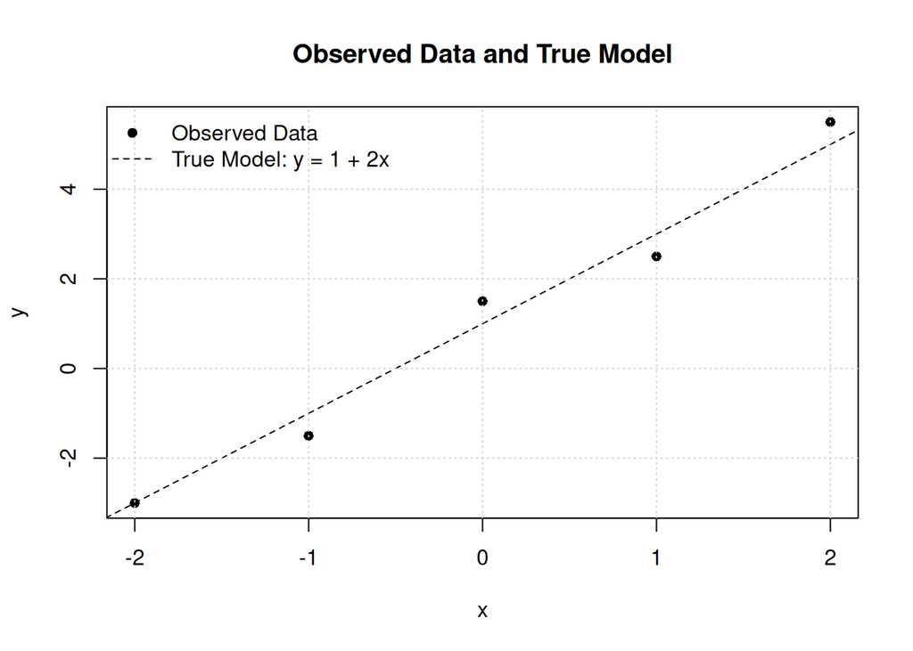

```r
### プロット
x_model <- seq(min(x_val) - 1, max(x_val) + 1, length.out = 100)
y_true_model <- 1 + 2 * x_model

plot(x_val, y_val, pch = 16, xlab = "x", ylab = "y",
     main = "Observed Data and True Model")
lines(x_model, y_true_model, lty = 2)
grid()
legend("topleft",
       legend = c("Observed Data", "True Model: y = 1 + 2x"),
       pch = c(16, NA), lty = c(NA, 2), bty = "n")
```

## 6.1 OLS推定量の計算

$$\begin{alignat}{2}
\hat{\beta}&=(X'X)^{-1}X'y\\
SSE &= (y - X\hat{\beta})'(y - X\hat{\beta})\\
\nu &= N-k && \quad \text{(Koop 3.4)}\\
s &= \frac{SSE}{\nu}
\end{alignat}$$

```r
XTX <- t(X) %*% X
XTy <- t(X) %*% y
beta_hat <- solve(XTX, XTy)
SSE <- sum((y - X %*% beta_hat)^2)
s2_ols <- SSE / (n - k)
cat("OLS betahat:\n"); print(beta_hat)
```

```
## OLS betahat:
##       [,1]
##        1.0
## x_val  2.1
```

## 6.2 尤度関数 数値例

```r
### 尤度関数
calculate_likelihood <- function(beta, h, y, X) {
  N <- length(y)
  constant_part <- (h / (2 * pi))^(N / 2) # (h/2pi)^(N/2)
  residual <- y - X %*% beta
  sse <- t(residual) %*% residual
  exponential_part <- exp(- h/2 * sse)
  as.numeric(constant_part * exponential_part)
}
```

```r
### 尤度関数プロット
beta1_range <- seq(-0.5, 2.5, length.out = 11)

h_values <- c(1.0, 2.0, 3.0)
cols <- c("blue", "green", "red")
labs <- paste0("h = ", h_values)

# plot(NA, xlim = range(beta1_range), ylim = c(0, NA),
#      xlab = expression(beta[1]),
#      ylab = expression(L(beta[1]~"|"~beta[0]==1,~h)),
#      main = expression("Likelihood function  " * L(beta[1]~"|"~beta[0]==1,~h)))

# for (i in seq_along(h_values)) {
#   h_val <- h_values[i]
#   kernel_values <- numeric(length(beta1_range))
#   for (j in seq_along(beta1_range)) {
#     beta1_val <- beta1_range[j]
#     beta_vector <- matrix(c(beta_true[1,1], beta1_val), ncol = 1)
#     kernel_values[j] <- calculate_likelihood(beta_vector, h_val, y, X)
#   }
#   lines(beta1_range, kernel_values, type = "b", col = cols[i])
# }
#
# grid()
# legend("topright", legend = labs, col = cols, lty = 1, pch = 1, bty = "n")
```

## 6.3 Gamma分布 数値例

$$\begin{aligned}
\underline{\beta} &= \begin{pmatrix}0.0\\0.0\end{pmatrix},\\
\underline{Q} &= \begin{bmatrix}1 & 0\\ 0 &
1\end{bmatrix},\\
\underline{\nu} &= \quad 2.0,\\
\underline{s}^2 &= \quad 0.5.
\end{aligned}$$

```r
# 3. 事前分布パラメータ (Informative Prior: Normal-Gamma)
beta_prior <- matrix(c(0.0, 0.0), ncol = 1) # 事前平均: beta = [0, 0]'
Q_prior <- diag(k) * 1.0                   # 事前精度行列 Q (確信度): Q = diag(1, 1)
nu_prior <- 2.0                            # 事前自由度/スケール
s2_prior <- 0.5                            # 事前分散の目安 E[sigma^2] = 0.5 -> E[h] = 2
```

```r
calculate_h_prior_kernel <- function(h_param, nu, s2) {
  alpha <- nu / 2.0
  beta  <- (nu * s2) / 2.0
  if (h_param <= 0) return(0.0)
  (h_param^(alpha - 1)) * exp(-beta * h_param)
}
```

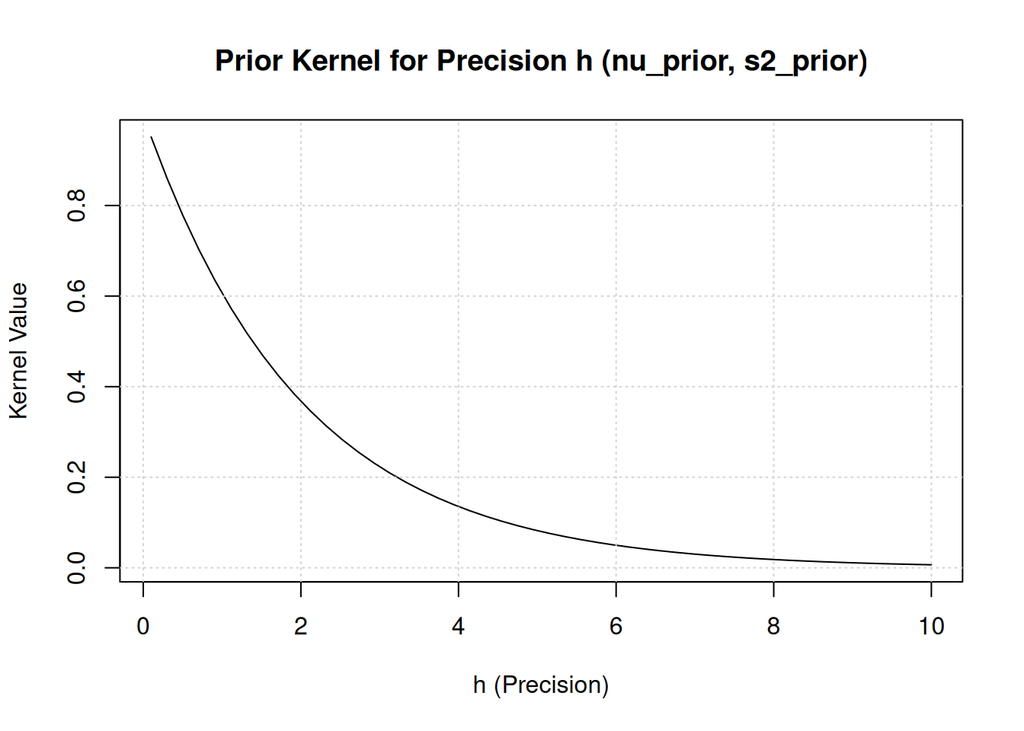

```r
h_range <- seq(0.1, 10.0, length.out = 50)

# 計算結果を保存するリスト
kernel_values_h <- numeric(length(h_range))

for (i in seq_along(h_range)) {
  h_point <- h_range[i]
  kernel_values_h[i] <- calculate_h_prior_kernel(h_point, nu_prior, s2_prior)
}

# 結果をプロット
plot(h_range, kernel_values_h, type = "l",
     xlab = "h (Precision)", ylab = "Kernel Value",
     main = "Prior Kernel for Precision h (nu_prior, s2_prior)")
grid()
```

## 6.4 正規分布 数値例

```r
calculate_conditional_posterior_beta_kernel <- function(beta, beta_bar, h, Q_bar) {
  k <- length(beta)
  deviation <- beta - beta_bar
  quadratic_form <- t(deviation) %*% Q_bar %*% deviation
  as.numeric((h^(k/2)) * exp(-0.5 * h * quadratic_form[1,1]))
}
```

```r
#
# beta1_range <- seq(-0.5, 2.5, length.out = 11)
# beta0_fixed <- 1.0
#
# h_values <- c(1.0, 2.0, 3.0)
# cols <- c("blue", "green", "red")
# labs <- paste0("h = ", h_values)
#
# plot(NA, xlim = range(beta1_range), ylim = c(0, NA),
#      xlab = expression(beta[1]), ylab = "Kernel Value",
#      main = expression("Posterior Kernel for " * beta[1] * " (" * beta[0]==1.0 * ", Prior)"))
#
# for (i in seq_along(h_values)) {
#   h_val <- h_values[i]
#   kernel_values <- numeric(length(beta1_range))
#   for (j in seq_along(beta1_range)) {
#     beta1_val <- beta1_range[j]
#     beta_vector <- matrix(c(beta0_fixed, beta1_val), ncol = 1)
#     kernel_values[j] <- calculate_conditional_posterior_beta_kernel(beta_vector, beta_prior, h_val, Q_prior)
#   }
#   lines(beta1_range, kernel_values, type = "b", col = cols[i])
# }
#
# grid()
# legend("topright", legend = labs, col = cols, lty = 1, pch = 1, bty = "n")
```

- hにconditionづければ、betaのposteriorも正規分布…“自然共役”

## 6.5 解析解

```r
# Call the function with existing data and prior parameters
post <- calculate_bayesian_analytical_solution(y, X, beta_prior, Q_prior, nu_prior, s2_prior)

beta_post_analytical <- post$beta_posterior
Q_post_analytical    <- post$Q_posterior
nu_post_analytical   <- post$nu_posterior
s2_post_analytical   <- post$s2_posterior

cat("Analytical Posterior Mean for Beta:\n"); print(beta_post_analytical)
cat("\nAnalytical Posterior Precision Matrix for Beta (Q_posterior):\n"); print(Q_post_analytical)
cat("\nAnalytical Posterior Degrees of Freedom (nu_posterior):", nu_post_analytical, "\n")
cat("\nAnalytical Posterior Scale for Sigma^2 (s2_posterior):", s2_post_analytical, "\n")
```

```
## Analytical Posterior Mean for Beta:
##            [,1]
##       0.8333333
## x_val 1.9090909
##
## Analytical Posterior Precision Matrix for Beta (Q_posterior):
##         x_val
##       6     0
## x_val 0    11
##
## Analytical Posterior Degrees of Freedom (nu_posterior): 7
##
## Analytical Posterior Scale for Sigma^2 (s2_posterior): 0.9632035
```

```r
#
# # Parameters for the marginal posterior t-distribution of beta_1
# df_beta1 <- nu_post_analytical
# loc_beta1 <- beta_post_analytical[2,1]  # beta_1 is the 2nd element
#
# # Calculate the inverse of Q_post_analytical
# inv_Q_post_analytical <- solve(Q_post_analytical)
#
# # NOTE:
# # In the original ipynb cell, the line after `if nu_post_analytical > 2:` was abbreviated as `...`.
# # Here we fill it using the standard conjugate Normal-Gamma result:
# # marginal beta_j | y ~ t_{nu_post}(mean = beta_post[j], scale = sqrt(s2_post * (Q_post^{-1})[j,j])).
#
# if (nu_post_analytical > 2) {
#   scale_beta1_std <- sqrt(s2_post_analytical * inv_Q_post_analytical[2,2])
# } else {
#   scale_beta1_std <- NA_real_
# }
#
# beta1_range <- seq(-0.5, 3.5, length.out = 200)
#
# # R's dt() has no (loc, scale), so we apply the location-scale transform explicitly:
# posterior_pdf_values <- dt((beta1_range - loc_beta1)/scale_beta1_std, df = df_beta1) / scale_beta1_std
#
# plot(beta1_range, posterior_pdf_values, type = "l",
#      xlab = expression(eta[1]), ylab = "Density",
#      main = expression("Marginal Posterior PDF for " * eta[1]))
# abline(v = beta_true[2,1], lty = 2, col = "red")
# abline(v = beta_hat[2,1],  lty = 3, col = "green")
# abline(v = loc_beta1,      lty = 4, col = "blue")
# grid()
# legend("topright",
#        legend = c(
#          sprintf("True eta_1 (%.1f)", beta_true[2,1]),
#          sprintf("OLS betahat_1 (%.1f)", beta_hat[2,1]),
#          sprintf("Posterior Mean beta_1 (%.2f)", loc_beta1)
#        ),
#        lty = c(2,3,4), col = c("red","green","blue"), bty = "n")
```

## 6.6 シミュレーション

```r
beta1_grid <- seq(-1, 3, length.out = 100)
h_grid <- seq(0.1, 10, length.out = 100)
grid_df <- expand.grid(beta1 = beta1_grid, h = h_grid)

cat("beta1_grid length:", length(beta1_grid), "\n")
cat("h_grid length:", length(h_grid), "\n")
cat("grid_df rows:", nrow(grid_df), "\n")
```

```
## beta1_grid length: 100
## h_grid length: 100
## grid_df rows: 10000
```

```r
# Likelihood on the (beta1, h) grid
grid_df$likelihood <- 0.0

for (r in seq_len(nrow(grid_df))) {
  beta1_val <- grid_df$beta1[r]
  h_val <- grid_df$h[r]
  beta_vector <- matrix(c(beta_true[1,1], beta1_val), ncol = 1)
  if (h_val > 0) {
    grid_df$likelihood[r] <- calculate_likelihood(beta_vector, h_val, y, X)
  } else {
    grid_df$likelihood[r] <- 0
  }
}

cat("Likelihood values calculated.\n")
```

```
## Likelihood values calculated.
```

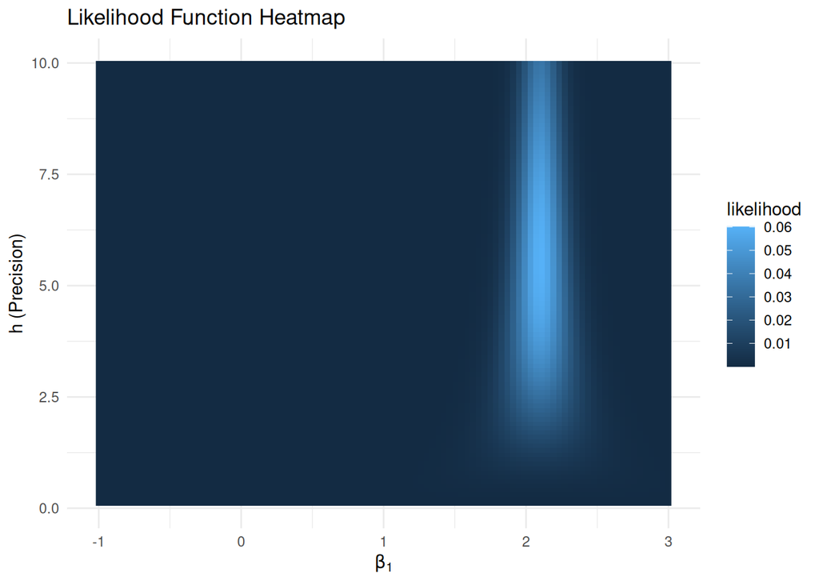

```r
# Heatmap: likelihood
ggplot(grid_df, aes(x = beta1, y = h, fill = likelihood)) +
  geom_raster() +
  labs(
    title = "Likelihood Function Heatmap",
    x = expression(beta[1]),
    y = "h (Precision)"
  ) +
  theme_minimal()
```

```r
# Prior on the (beta1, h) grid
grid_df$prior <- 0.0

for (r in seq_len(nrow(grid_df))) {
  beta1_val <- grid_df$beta1[r]
  h_val <- grid_df$h[r]

  beta_vector <- matrix(c(beta_prior[1,1], beta1_val), ncol = 1)

  if (h_val > 0) {
    h_prior_kernel <- calculate_h_prior_kernel(h_val, nu_prior, s2_prior)
    beta_conditional_prior_kernel <- calculate_conditional_posterior_beta_kernel(
      beta_vector, beta_prior, h_val, Q_prior
    )
    grid_df$prior[r] <- h_prior_kernel * beta_conditional_prior_kernel
  } else {
    grid_df$prior[r] <- 0
  }
}

cat("Prior values calculated.\n")
```

```
## Prior values calculated.
```

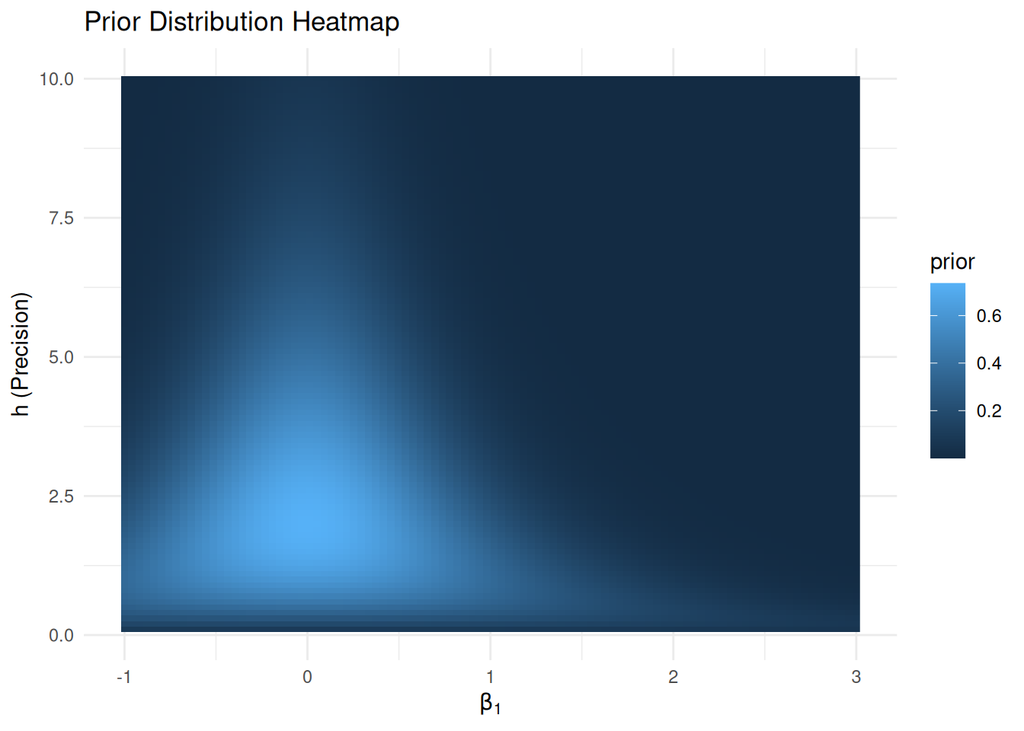

```r
ggplot(grid_df, aes(x = beta1, y = h, fill = prior)) +
  geom_raster() +
  labs(
    title = "Prior Distribution Heatmap",
    x = expression(beta[1]),
    y = "h (Precision)"
  ) +
  theme_minimal()
```

```r
# Posterior (normalized on the grid)
posterior_unnorm <- grid_df$likelihood * grid_df$prior
sum_post <- sum(posterior_unnorm)

if (sum_post > 0) {
  grid_df$posterior <- posterior_unnorm / sum_post
} else {
  grid_df$posterior <- 0
}

cat("Posterior values calculated.\n")
cat("Sum of posterior values (after normalization):", sum(grid_df$posterior), "\n")
```

```
## Posterior values calculated.
## Sum of posterior values (after normalization): 1
```

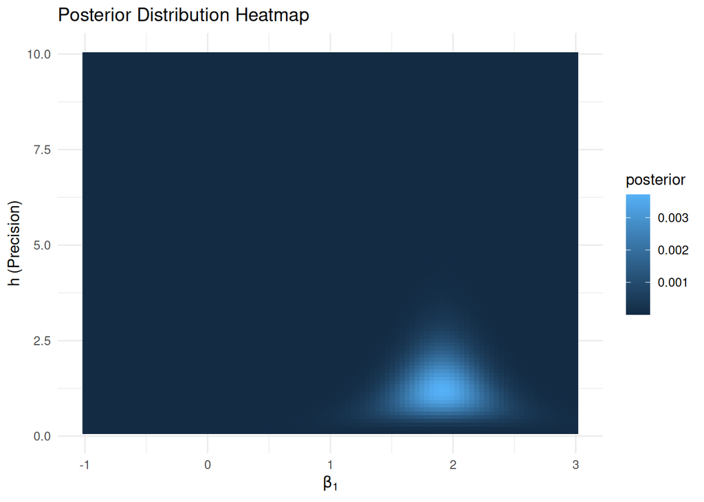

```r
ggplot(grid_df, aes(x = beta1, y = h, fill = posterior)) +
  geom_raster() +
  labs(
    title = "Posterior Distribution Heatmap",
    x = expression(beta[1]),
    y = "h (Precision)"
  ) +
  theme_minimal()
```

## 6.7 Gibbs Sampling

結合事後分布：

$$\boxed{p(\beta,h\mid y) \propto h^{\frac{k+\bar{\nu}-2}{2}} \exp\Bigg[
-\frac{h}{2}\Big\{
(\beta-\bar{\beta})'\bar{Q}^{-1}(\beta-\bar{\beta})+\bar{\nu}
\bar{s}^2
\Big\} \Bigg]\quad \text{（再掲）}}$$

ここでは、条件付き事後分布のパラメータを$\{\dot{\beta},\dot{Q},\dot{\nu},\dot{s}\}$と書く。

$\beta$の条件付き事後分布は、解析解で導出済み。すなわち、

$$\boxed{\beta|h \sim N(\dot{\beta},h^{-1}\dot Q),}$$
$$\text{where}\quad \begin{aligned}
\dot{Q} &= \bar{Q} = (\underline{Q}^{-1}+X'X)^{-1},\\
\dot{\beta} &= \bar{\beta}=
\bar{Q}(\underline{Q}^{-1}\underline{\beta}+X'X\hat{\beta}).
\end{aligned}$$

一方、$h$については$\beta$を定数項として扱うことで、下記のパラメータに従うGamma分布として定義できる:

$$\boxed{h|\beta \sim \gamma(\dot{s}^{-2},\dot{\nu}),}$$

$$\begin{aligned}
\dot{\nu}&=\underbrace{\bar{\nu}}_{\underline{\nu}+N}+k,\\
\dot{\nu}\dot{s}^2 &= \underbrace{\bar{\nu}\bar{s}^2}_{
\underline{\nu}\underline{s}^{2}+\hat{\nu}
\hat{s}^2+(\underline{\beta}-\bar{\beta})'\underline{Q}^{-1}(\underline{\beta}-\bar{\beta}) }+({\beta}-\bar{\beta})'\dot{Q}^{-1}({\beta}-\bar{\beta}).
\end{aligned}$$

$\dot{\nu}\dot{s}^2$は、$h$のmarginal posteriorのパラメータ $\bar{\nu} \bar{s}^2$ に$\beta$に依存する$({\beta}-\bar{\beta})'\bar{Q}^{-1}({\beta}-\bar{\beta})$を足したもの。

#### 6.7.0.1 アルゴリズム

- 初期化： $h^{(0)} > 0$ を与える（例：$h^{(0)}=1$）。以後 $s=1,...,S$ を反復。
- Step 1（$\beta | h, y$ をドロー）： $\beta^{(s)} \sim N( \dot\beta , (h^{(s-1)})^{-1} \dot Q )$

  （直前の $h^{(s-1)}$ を固定して多変量正規分布からサンプル。）
- Step 2（$h | \beta, y$ をドロー）：

  $h^{(s)} \sim \gamma( \dot s^{-2} , \dot \nu)$, where $\dot \nu = \bar \nu + k$, $\dot \nu \dot s^2 = \bar{\nu} \bar{s}^2 + (\beta^{(s)} - \bar{\beta})'\dot{Q}^{-1}(\beta^{(s)} - \bar{\beta})$.

  （Step 1 の $\beta^{(s)}$ を固定して Gamma 分布からサンプル。）
- 反復：

  上の Step 1–2 を $S$ 回繰り返すと、$\{(\beta^{(s)}, h^{(s)})\}$は $p(\beta,h|y)$ のサンプル列になる （バーンインは適宜捨てる）。

上でみたとおり、それぞれの条件付き分布のうち、**可変のパラメータは**$\beta$**の**$h^{(s)}$**と**$h$**の**$\dot{s}$**（**$\beta^{(s)}$**を通じて変動）のみ。それ以外のパラメータ**（$\dot{\beta}, \, \dot{Q}, \, \dot{\nu}$）**はループを通じて不変**。

**メモ**: $\gamma(\dot{s}^{-2} , \dot{\nu})$ と $\Gamma(\text{shape}, \text{rate})$ の対応（R の `rgamma` は shape-rate）

BEM流に$h|\beta, y \sim \gamma( \dot s^{-2} , \dot \nu)$と書くとき、これは密度の核が

$$p(h|\beta,y) \propto h ^{{\dot{\nu}}/2-1} \exp
\left[-\frac{\dot{\nu}\dot{s}^2}{2}\right], \quad h>0$$

したがって、Rの`rgamma`で書くと
$$h \sim \Gamma\left(\text{shape}=\dot{\nu}/2, \,\text{rate}=
\frac{\dot{\nu}\dot{s}^2}{2}\right)$$

- scaleを使う実装では rate = 1/scaleなので、$\text{scale} = 2 / (\dot{\nu}\dot{s}^2)$。

#### 6.7.0.2 実装

下記はGibbs samplerを実装する関数。

```r
# Gibbs sampler as a function (Normal–Gamma regression posterior)
#   beta | h, y  ~ N(beta_bar, h^{-1} Q_bar)
#   h | beta, y  ~ Gamma(shape = (nu_bar + k)/2,
#                        rate  = (nu_bar*s2_bar + (beta-beta_bar)'Q_bar^{-1}(beta-beta_bar))/2)

gibbs_ng <- function(beta_bar, Q_bar, nu_bar, s2_bar,
                     h_init = 1.0, n_samples = 1000, seed = NULL) {
  if (!is.null(seed)) set.seed(seed)

  k <- nrow(beta_bar)
  Qbar_inv <- solve(Q_bar)

  # variables to store the results
  beta1 <- numeric(n_samples)
  h_draw <- numeric(n_samples)

  ### initial h ###
  current_h <- h_init

  ### Gibbs iteration ###
  for (s in seq_len(n_samples)) {
    ### Step 1: draw beta | h, y ###
    cov_beta <- Q_bar / current_h  # (h^{-1} Q_bar)
    b <- MASS::mvrnorm(n = 1, mu = as.numeric(beta_bar), Sigma = cov_beta)

    # update b -> store beta1 (2nd element)
    b <- matrix(b, ncol = 1)
    beta1[s] <- b[2, 1]

    ### Step 2: draw h | beta, y  ###
    quad <- as.numeric(t(b - beta_bar) %*% Qbar_inv %*% (b - beta_bar))  # scalar
    shape_h <- (nu_bar + k) / 2
    rate_h  <- (nu_bar * s2_bar + quad) / 2

    # update h -> store
    current_h <- rgamma(1, shape = shape_h, rate = rate_h)
    h_draw[s] <- current_h
  }

  # return
  data.frame(
    iter   = seq_len(n_samples),
    beta1  = beta1,
    h      = h_draw,
    h_init = h_init
  )
}
```

$h^{(0)}=(1, 10000, 0.001)$の3パターンで実行。

ポイント：

- どの初期値から始めても早々に収束
- $h$が小さい（分散が大きい）→$\beta^{(1)}$の分散が大きくなり、収束に数回要している
- $h$が大きい（分散が小さい）→posterior mean（$\bar \beta$）にかなり近い$\beta^{(1)}$のを引くため、すぐに収束

```r
h_inits <- c(1, 10000, 0.001)

trace_list <- lapply(h_inits, function(h0) {
  gibbs_ng(
    beta_bar = beta_post_analytical,
    Q_bar    = Q_post_analytical,
    nu_bar   = nu_post_analytical,
    s2_bar   = s2_post_analytical,
    h_init   = h0,
    n_samples = 1000
  )
})

trace_df <- do.call(rbind, trace_list)
trace_df$h_init <- factor(trace_df$h_init, levels = as.character(h_inits))
```

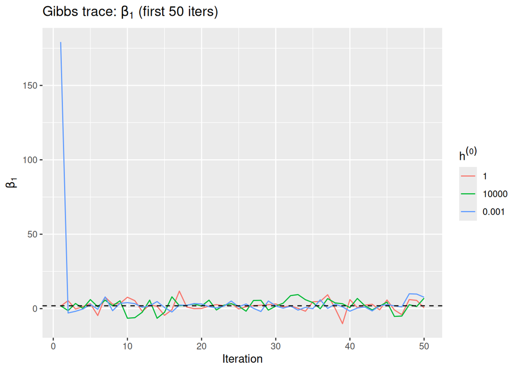

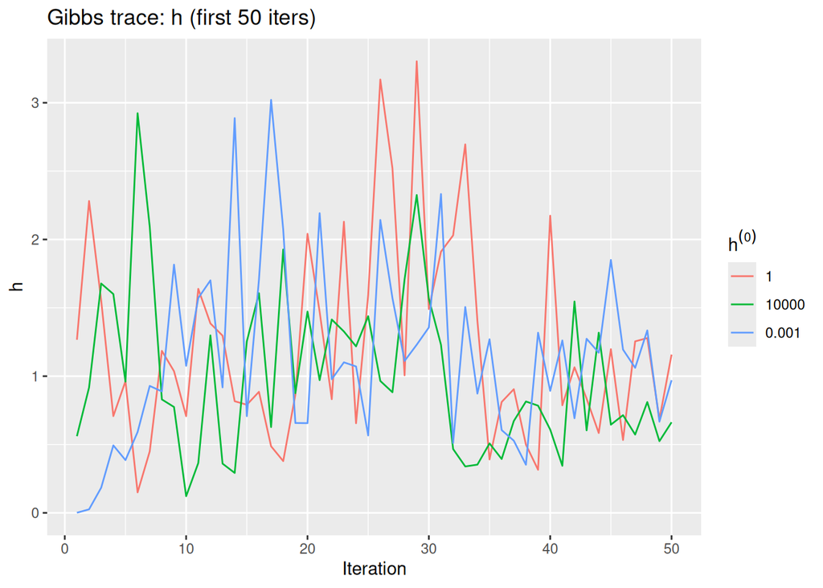

```r
# focus window (change if you want longer)
trace_df_100 <- subset(trace_df, iter <= 50)

# reference line for beta1 (analytical posterior mean)
beta1_ref <- beta_post_analytical[2, 1]

# Plot: beta1 trace (3 chains)
p_beta <- ggplot(trace_df_100, aes(x = iter, y = beta1, color = h_init)) +
  geom_line() +
  geom_hline(yintercept = beta1_ref, linetype = 2) +
  labs(
    title = expression("Gibbs trace: " * beta[1] * " (first 50 iters)"),
    x = "Iteration",
    y = expression(beta[1]),
    color = expression(h^{(0)})
  )

# Plot: h trace (3 chains)
p_h <- ggplot(trace_df_100, aes(x = iter, y = h, color = h_init)) +
  geom_line() +
  labs(
    title = "Gibbs trace: h (first 50 iters)",
    x = "Iteration",
    y = "h",
    color = expression(h^{(0)})
  )

print(p_beta)
print(p_h)
```

# 7 数学補足

## 7.1 1.

一般的に、
$$\begin{aligned}
&(\beta-\beta_1)'V_1(\beta-\beta_1)+(\beta-\beta_2)'V_2(\beta-\beta_2)
\\[1em]
=& \beta'V_1\beta - 2
\beta'V_1\beta_1+\beta_1'V_1\beta_1+\beta'V_2\beta - 2
\beta'V_2\beta_2+\beta_2'V_2\beta_2\\[1em]
=& \beta'(\underbrace{ V_1+V_2 }_{\equiv \bar{V}})\beta -2
\beta'(\underbrace{ V_1\beta_1+V_2\beta_2 }_{\equiv b})+\underbrace{
\beta_1'V_1\beta_1+\beta_2'V_2\beta_2 }_{\equiv C}\\
=&\beta' \bar{V} \beta-2\beta'b+C.
\end{aligned}$$
ここで、$b = \bar{V}\bar{\beta}$とおくと、
$$\begin{aligned}
&\beta' \bar{V} \beta -2 \beta'\bar{V} \bar{\beta}+C\\[1em]
=&(\beta-\bar{\beta})'\bar{V}(\beta-\bar{\beta})+C-\bar{\beta}'\bar{V}\bar{\beta}'
\end{aligned}$$
さらに、
$$\begin{aligned}
&(\beta_1-\bar{\beta})'V_1(\beta_1-\bar{\beta})+(\beta_2-\bar{\beta})'V_2(\beta_2-\bar{\beta})\\[1em]
=&\beta_1'V_1\beta_1+\beta_2'V_2\beta_2-2\bar{\beta}'(\underbrace{
V_1\beta_1+V_2\beta_2 }_{=b})+\bar{\beta}'(V_1+V_2)\bar{\beta}\\
=&\beta_1'V_1\beta_1+\beta_2'V_2\beta_2-2\underbrace{
\bar{\beta}'\bar{V}\bar{\beta}
}_{=\bar{\beta}'b}+\bar{\beta}'\bar{V}\bar{\beta}\\
=&\beta_1'V_1\beta_1+\beta_2'V_2\beta_2-\bar{\beta}'\bar{V}\bar{\beta}\\[1em]
=&C-\bar{\beta}'\bar{V}\bar{\beta}.
\end{aligned}$$
よって、

$$(\beta-\beta_1)'V_1(\beta-\beta_1)+(\beta-\beta_2)'V_2(\beta-\beta_2)=(\beta-\bar{\beta})'\bar{V}(\beta-\bar{\beta})+(\beta_1-\bar{\beta})'V_1(\beta_1-\bar{\beta})+(\beta_2-\bar{\beta})'V_2(\beta_2-\bar{\beta}),$$

$$\begin{aligned}
&\bar{V} = V_1+V_2,\\
&\bar{\beta} = \bar{V}^{-1}(V_1\beta_1+V_2\beta_2)
\end{aligned}$$

## 7.2 2. 尤度の計算（未）